# ML Logistic Regression project

#Logistic Regression Project

In this project we will be working with the UCI adult dataset. We will be attempting to predict if people in the data set belong in a certain class by salary, either making <=50k or >50k per year. Typically most of your time is spent cleaning data, not running the few lines of code that build your model, this project will try to reflect that by showing different issues that may arise when cleaning data.

## Get the Data

### Read in the adult_sal.csv file and set it to a data frame called adult.

```r
remove(list = ls())
adult <- read.csv("/Users/sobil/Documents/Certifications/DataScienceAndMachineLearningBootcampWithRUdemy/Notes/Training Exercises/Machine Learning Projects/CSV files for ML Projects/adult_sal.csv")
```

### Check the head of adult

```r
head(adult)
```

|  | X | age | type_employer | fnlwgt | education | education_num | marital | occupation | relationship | race | sex | capital_gain | capital_loss | hr_per_week | country | income |
| --- | --- | --- | --- | --- | --- | --- | --- | --- | --- | --- | --- | --- | --- | --- | --- | --- |
| 1 | 1 | 39 | State-gov | 77516 | Bachelors | 13 | Never-married | Adm-clerical | Not-in-family | White | Male | 2174 | 0 | 40 | United-States | <=50K |
| 2 | 2 | 50 | Self-emp-not-inc | 83311 | Bachelors | 13 | Married-civ-spouse | Exec-managerial | Husband | White | Male | 0 | 0 | 13 | United-States | <=50K |
| 3 | 3 | 38 | Private | 215646 | HS-grad | 9 | Divorced | Handlers-cleaners | Not-in-family | White | Male | 0 | 0 | 40 | United-States | <=50K |
| 4 | 4 | 53 | Private | 234721 | 11th | 7 | Married-civ-spouse | Handlers-cleaners | Husband | Black | Male | 0 | 0 | 40 | United-States | <=50K |
| 5 | 5 | 28 | Private | 338409 | Bachelors | 13 | Married-civ-spouse | Prof-specialty | Wife | Black | Female | 0 | 0 | 40 | Cuba | <=50K |
| 6 | 6 | 37 | Private | 284582 | Masters | 14 | Married-civ-spouse | Exec-managerial | Wife | White | Female | 0 | 0 | 40 | United-States | <=50K |

### You should notice the index has been repeated. Drop this column.

```r
adult <- adult[,c(-1)]
```

### Check the head,str, and summary of the data now.

```r
head(adult)
```

|  | age | type_employer | fnlwgt | education | education_num | marital | occupation | relationship | race | sex | capital_gain | capital_loss | hr_per_week | country | income |
| --- | --- | --- | --- | --- | --- | --- | --- | --- | --- | --- | --- | --- | --- | --- | --- |
| 1 | 39 | State-gov | 77516 | Bachelors | 13 | Never-married | Adm-clerical | Not-in-family | White | Male | 2174 | 0 | 40 | United-States | <=50K |
| 2 | 50 | Self-emp-not-inc | 83311 | Bachelors | 13 | Married-civ-spouse | Exec-managerial | Husband | White | Male | 0 | 0 | 13 | United-States | <=50K |
| 3 | 38 | Private | 215646 | HS-grad | 9 | Divorced | Handlers-cleaners | Not-in-family | White | Male | 0 | 0 | 40 | United-States | <=50K |
| 4 | 53 | Private | 234721 | 11th | 7 | Married-civ-spouse | Handlers-cleaners | Husband | Black | Male | 0 | 0 | 40 | United-States | <=50K |
| 5 | 28 | Private | 338409 | Bachelors | 13 | Married-civ-spouse | Prof-specialty | Wife | Black | Female | 0 | 0 | 40 | Cuba | <=50K |
| 6 | 37 | Private | 284582 | Masters | 14 | Married-civ-spouse | Exec-managerial | Wife | White | Female | 0 | 0 | 40 | United-States | <=50K |

```r
str(adult)
```

```
'data.frame':   32561 obs. of  15 variables:
 $ age          : int  39 50 38 53 28 37 49 52 31 42 ...
 $ type_employer: Factor w/ 9 levels "?","Federal-gov",..: 8 7 5 5 5 5 5 7 5 5 ...
 $ fnlwgt       : int  77516 83311 215646 234721 338409 284582 160187 209642 45781 159449 ...
 $ education    : Factor w/ 16 levels "10th","11th",..: 10 10 12 2 10 13 7 12 13 10 ...
 $ education_num: int  13 13 9 7 13 14 5 9 14 13 ...
 $ marital      : Factor w/ 7 levels "Divorced","Married-AF-spouse",..: 5 3 1 3 3 3 4 3 5 3 ...
 $ occupation   : Factor w/ 15 levels "?","Adm-clerical",..: 2 5 7 7 11 5 9 5 11 5 ...
 $ relationship : Factor w/ 6 levels "Husband","Not-in-family",..: 2 1 2 1 6 6 2 1 2 1 ...
 $ race         : Factor w/ 5 levels "Amer-Indian-Eskimo",..: 5 5 5 3 3 5 3 5 5 5 ...
 $ sex          : Factor w/ 2 levels "Female","Male": 2 2 2 2 1 1 1 2 1 2 ...
 $ capital_gain : int  2174 0 0 0 0 0 0 0 14084 5178 ...
 $ capital_loss : int  0 0 0 0 0 0 0 0 0 0 ...
 $ hr_per_week  : int  40 13 40 40 40 40 16 45 50 40 ...
 $ country      : Factor w/ 42 levels "?","Cambodia",..: 40 40 40 40 6 40 24 40 40 40 ...
 $ income       : Factor w/ 2 levels "<=50K",">50K": 1 1 1 1 1 1 1 2 2 2 ...
```

```r
summary(adult)
```

```
      age                 type_employer       fnlwgt               education     education_num                    marital                occupation
 Min.   :17.00   Private         :22696   Min.   :  12285   HS-grad     :10501   Min.   : 1.00   Divorced             : 4443   Prof-specialty :4140
 1st Qu.:28.00   Self-emp-not-inc: 2541   1st Qu.: 117827   Some-college: 7291   1st Qu.: 9.00   Married-AF-spouse    :   23   Craft-repair   :4099
 Median :37.00   Local-gov       : 2093   Median : 178356   Bachelors   : 5355   Median :10.00   Married-civ-spouse   :14976   Exec-managerial:4066
 Mean   :38.58   ?               : 1836   Mean   : 189778   Masters     : 1723   Mean   :10.08   Married-spouse-absent:  418   Adm-clerical   :3770
 3rd Qu.:48.00   State-gov       : 1298   3rd Qu.: 237051   Assoc-voc   : 1382   3rd Qu.:12.00   Never-married        :10683   Sales          :3650
 Max.   :90.00   Self-emp-inc    : 1116   Max.   :1484705   11th        : 1175   Max.   :16.00   Separated            : 1025   Other-service  :3295
                 (Other)         :  981                     (Other)     : 5134                   Widowed              :  993   (Other)        :9541
         relationship                   race           sex         capital_gain    capital_loss     hr_per_week             country        income
 Husband       :13193   Amer-Indian-Eskimo:  311   Female:10771   Min.   :    0   Min.   :   0.0   Min.   : 1.00   United-States:29170   <=50K:24720
 Not-in-family : 8305   Asian-Pac-Islander: 1039   Male  :21790   1st Qu.:    0   1st Qu.:   0.0   1st Qu.:40.00   Mexico       :  643   >50K : 7841
 Other-relative:  981   Black             : 3124                  Median :    0   Median :   0.0   Median :40.00   ?            :  583
 Own-child     : 5068   Other             :  271                  Mean   : 1078   Mean   :  87.3   Mean   :40.44   Philippines  :  198
 Unmarried     : 3446   White             :27816                  3rd Qu.:    0   3rd Qu.:   0.0   3rd Qu.:45.00   Germany      :  137
 Wife          : 1568                                             Max.   :99999   Max.   :4356.0   Max.   :99.00   Canada       :  121
                                                                                                                   (Other)      : 1709
```

## Data Cleaning

Notice that we have a lot of columns that are cateogrical factors, however a lot of these columns have too many factors than may be necessary. In this data cleaning section we’ll try to clean these columns up by reducing the number of factors.

### Use table() to check out the frequency of the type_employer column.

```r
table(adult$type_employer)
```

```
               ?      Federal-gov        Local-gov     Never-worked          Private     Self-emp-inc Self-emp-not-inc        State-gov      Without-pay
            1836              960             2093                7            22696             1116             2541             1298               14
```

### How many Null values are there for type_employer? What are the two smallest groups?

Null = 1836 2 smallest group = Never-worked and Without-pay

### Combine these two smallest groups into a single group called “Unemployed”. There are lots of ways to do this, so feel free to get creative. Hint: It may be helpful to convert these objects into character data types (as.character() and then use sapply with a custom function)

```r
table(adult$type_employer)
```

```
               ?      Federal-gov        Local-gov          Private     Self-emp-inc Self-emp-not-inc        State-gov       Unemployed
            1836              960             2093            22696             1116             2541             1298               21
```

### What other columns are suitable for combining? Combine State and Local gov jobs into a category called SL-gov and combine self-employed jobs into a category called self-emp.

```r
table(adult$type_employer)
```

```
          ? Federal-gov     Private    self-emp      SL-gov  Unemployed
       1836         960       22696        3657        3391          21
```

## Marital Column

### Use table() to look at the marital column

```r
table(adult$marital)
```

```
             Divorced     Married-AF-spouse    Married-civ-spouse Married-spouse-absent         Never-married             Separated               Widowed
                 4443                    23                 14976                   418                 10683                  1025                   993
```

### Reduce this to three groups:

Married Not-Married Never-Married

```r
table(adult$marital)
```

```
      Married Never-married   Not-Married
        15417         10683          6461
```

## Country Column

### Check the country column using table()

```r
table(adult$country)
```

```
                         ?                   Cambodia                     Canada                      China                   Columbia
                       583                         19                        121                         75                         59
                      Cuba         Dominican-Republic                    Ecuador                El-Salvador                    England
                        95                         70                         28                        106                         90
                    France                    Germany                     Greece                  Guatemala                      Haiti
                        29                        137                         29                         64                         44
        Holand-Netherlands                   Honduras                       Hong                    Hungary                      India
                         1                         13                         20                         13                        100
                      Iran                    Ireland                      Italy                    Jamaica                      Japan
                        43                         24                         73                         81                         62
                      Laos                     Mexico                  Nicaragua Outlying-US(Guam-USVI-etc)                       Peru
                        18                        643                         34                         14                         31
               Philippines                     Poland                   Portugal                Puerto-Rico                   Scotland
                       198                         60                         37                        114                         12
                     South                     Taiwan                   Thailand            Trinadad&Tobago              United-States
                        80                         51                         18                         19                      29170
                   Vietnam                 Yugoslavia
                        67                         16
```

### Group these countries together however you see fit. You have flexibility here because there is no right/wrong way to do this, possibly group by continents. You should be able to reduce the number of groups here significantly though.

```r
levels(adult$country)
```

```
 [1] "?"                          "Cambodia"                   "Canada"                     "China"                      "Columbia"
 [6] "Cuba"                       "Dominican-Republic"         "Ecuador"                    "El-Salvador"                "England"
[11] "France"                     "Germany"                    "Greece"                     "Guatemala"                  "Haiti"
[16] "Holand-Netherlands"         "Honduras"                   "Hong"                       "Hungary"                    "India"
[21] "Iran"                       "Ireland"                    "Italy"                      "Jamaica"                    "Japan"
[26] "Laos"                       "Mexico"                     "Nicaragua"                  "Outlying-US(Guam-USVI-etc)" "Peru"
[31] "Philippines"                "Poland"                     "Portugal"                   "Puerto-Rico"                "Scotland"
[36] "South"                      "Taiwan"                     "Thailand"                   "Trinadad&Tobago"            "United-States"
[41] "Vietnam"                    "Yugoslavia"
```

```r
Asia <- c('China','Hong','India','Iran','Cambodia','Japan', 'Laos' ,
          'Philippines' ,'Vietnam' ,'Taiwan', 'Thailand')

North.America <- c('Canada','United-States','Puerto-Rico' )

Europe <- c('England' ,'France', 'Germany' ,'Greece','Holand-Netherlands','Hungary',
            'Ireland','Italy','Poland','Portugal','Scotland','Yugoslavia')

Latin.and.South.America <- c('Columbia','Cuba','Dominican-Republic','Ecuador',
                             'El-Salvador','Guatemala','Haiti','Honduras',
                             'Mexico','Nicaragua','Outlying-US(Guam-USVI-etc)','Peru',
                            'Jamaica','Trinadad&Tobago')
Other <- c('South')
```

```r
group_country <- function(ctry){
    if (ctry %in% Asia){
        return('Asia')
    }else if (ctry %in% North.America){
        return('North.America')
    }else if (ctry %in% Europe){
        return('Europe')
    }else if (ctry %in% Latin.and.South.America){
        return('Latin.and.South.America')
    }else{
        return('Other')
    }
}
```

```r
adult$country <- sapply(adult$country,group_country)
```

### Use table() to confirm the groupings

```r
table(adult$country)
```

```
                   Asia                  Europe Latin.and.South.America           North.America                   Other
                    671                     521                    1301                   29405                     663
```

### Check the str() of adult again. Make sure any of the columns we changed have factor levels with factor()

```r
str(adult)
```

```
'data.frame':   32561 obs. of  15 variables:
 $ age          : int  39 50 38 53 28 37 49 52 31 42 ...
 $ type_employer: chr  "SL-gov" "self-emp" "Private" "Private" ...
 $ fnlwgt       : int  77516 83311 215646 234721 338409 284582 160187 209642 45781 159449 ...
 $ education    : Factor w/ 16 levels "10th","11th",..: 10 10 12 2 10 13 7 12 13 10 ...
 $ education_num: int  13 13 9 7 13 14 5 9 14 13 ...
 $ marital      : chr  "Never-married" "Married" "Not-Married" "Married" ...
 $ occupation   : Factor w/ 15 levels "?","Adm-clerical",..: 2 5 7 7 11 5 9 5 11 5 ...
 $ relationship : Factor w/ 6 levels "Husband","Not-in-family",..: 2 1 2 1 6 6 2 1 2 1 ...
 $ race         : Factor w/ 5 levels "Amer-Indian-Eskimo",..: 5 5 5 3 3 5 3 5 5 5 ...
 $ sex          : Factor w/ 2 levels "Female","Male": 2 2 2 2 1 1 1 2 1 2 ...
 $ capital_gain : int  2174 0 0 0 0 0 0 0 14084 5178 ...
 $ capital_loss : int  0 0 0 0 0 0 0 0 0 0 ...
 $ hr_per_week  : int  40 13 40 40 40 40 16 45 50 40 ...
 $ country      : chr  "North.America" "North.America" "North.America" "North.America" ...
 $ income       : Factor w/ 2 levels "<=50K",">50K": 1 1 1 1 1 1 1 2 2 2 ...
```

```r
str(adult)
```

```
'data.frame':   32561 obs. of  15 variables:
 $ age          : int  39 50 38 53 28 37 49 52 31 42 ...
 $ type_employer: Factor w/ 6 levels "SL-gov","self-emp",..: 1 2 3 3 3 3 3 2 3 3 ...
 $ fnlwgt       : int  77516 83311 215646 234721 338409 284582 160187 209642 45781 159449 ...
 $ education    : Factor w/ 16 levels "10th","11th",..: 10 10 12 2 10 13 7 12 13 10 ...
 $ education_num: int  13 13 9 7 13 14 5 9 14 13 ...
 $ marital      : Factor w/ 3 levels "Never-married",..: 1 2 3 2 2 2 2 2 1 2 ...
 $ occupation   : Factor w/ 15 levels "?","Adm-clerical",..: 2 5 7 7 11 5 9 5 11 5 ...
 $ relationship : Factor w/ 6 levels "Husband","Not-in-family",..: 2 1 2 1 6 6 2 1 2 1 ...
 $ race         : Factor w/ 5 levels "Amer-Indian-Eskimo",..: 5 5 5 3 3 5 3 5 5 5 ...
 $ sex          : Factor w/ 2 levels "Female","Male": 2 2 2 2 1 1 1 2 1 2 ...
 $ capital_gain : int  2174 0 0 0 0 0 0 0 14084 5178 ...
 $ capital_loss : int  0 0 0 0 0 0 0 0 0 0 ...
 $ hr_per_week  : int  40 13 40 40 40 40 16 45 50 40 ...
 $ country      : Factor w/ 5 levels "North.America",..: 1 1 1 1 2 1 2 1 1 1 ...
 $ income       : Factor w/ 2 levels "<=50K",">50K": 1 1 1 1 1 1 1 2 2 2 ...
```

### We could still play around with education and occupation to try to reduce the number of factors for those columns, but let’s go ahead and move on to dealing with the missing data. Feel free to group thos columns as well and see how they effect your model.

# Missing Data

### Notice how we have data that is missing.

## Amelia

### Install and load the Amelia package.

```r
library(Amelia)
```

### Convert any cell with a ‘?’ or a ’ ?’ value to a NA value.

## Using table() on a column with NA values should now not display those NA values, instead you’ll just see 0 for ?. Optional: Refactor these columns (may take awhile). For example:

```r
table(adult$type_employer)
```

```
     SL-gov    self-emp     Private Federal-gov           ?  Unemployed
       3391        3657       22696         960           0          21
```

```r
adult$type_employer <- sapply(adult$type_employer,factor)
adult$country <- sapply(adult$country,factor)
adult$marital <- sapply(adult$marital,factor)
adult$occupation <- sapply(adult$occupation,factor)
```

### Play around with the missmap function from the Amelia package. Can you figure out what its doing and how to use it?

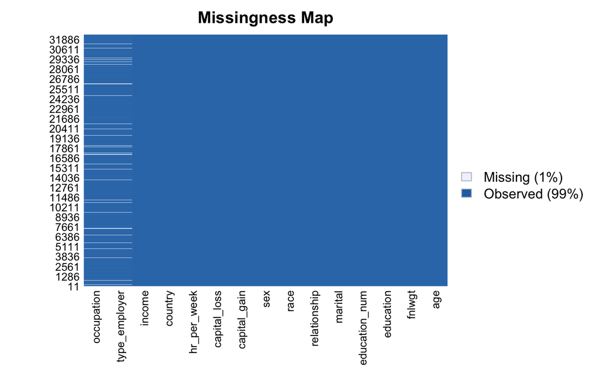

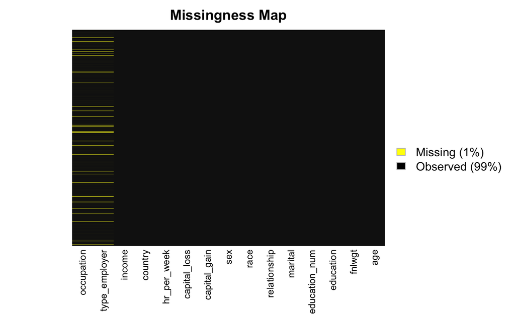

### Use na.omit() to omit NA data from the adult data frame. Note, it really depends on the situation and your data to judge whether or not this is a good decision. You shouldn’t always just drop NA values.

### Use missmap() to check that all the NA values were in fact dropped.

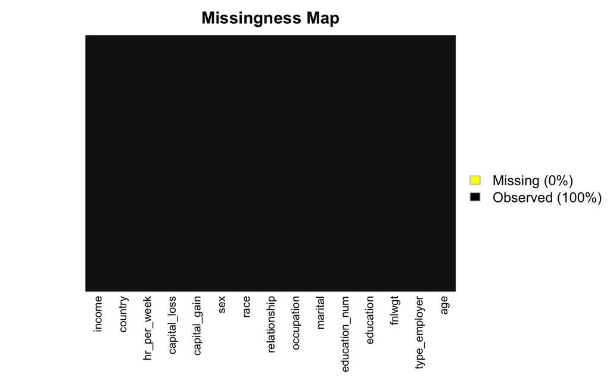

# EDA

Although we’ve cleaned the data, we still have explored it using visualization. ### Check the str() of the data.

```r
str(adult)
```

```
'data.frame':   30718 obs. of  15 variables:
 $ age          : int  39 50 38 53 28 37 49 52 31 42 ...
 $ type_employer: Factor w/ 5 levels "SL-gov","self-emp",..: 1 2 3 3 3 3 3 2 3 3 ...
 $ fnlwgt       : int  77516 83311 215646 234721 338409 284582 160187 209642 45781 159449 ...
 $ education    : Factor w/ 16 levels "10th","11th",..: 10 10 12 2 10 13 7 12 13 10 ...
 $ education_num: int  13 13 9 7 13 14 5 9 14 13 ...
 $ marital      : Factor w/ 3 levels "Never-married",..: 1 2 3 2 2 2 2 2 1 2 ...
 $ occupation   : Factor w/ 14 levels "Adm-clerical",..: 1 2 3 3 4 2 5 2 4 2 ...
 $ relationship : Factor w/ 6 levels "Husband","Not-in-family",..: 2 1 2 1 6 6 2 1 2 1 ...
 $ race         : Factor w/ 5 levels "Amer-Indian-Eskimo",..: 5 5 5 3 3 5 3 5 5 5 ...
 $ sex          : Factor w/ 2 levels "Female","Male": 2 2 2 2 1 1 1 2 1 2 ...
 $ capital_gain : int  2174 0 0 0 0 0 0 0 14084 5178 ...
 $ capital_loss : int  0 0 0 0 0 0 0 0 0 0 ...
 $ hr_per_week  : int  40 13 40 40 40 40 16 45 50 40 ...
 $ country      : Factor w/ 5 levels "North.America",..: 1 1 1 1 2 1 2 1 1 1 ...
 $ income       : Factor w/ 2 levels "<=50K",">50K": 1 1 1 1 1 1 1 2 2 2 ...
 - attr(*, "na.action")= 'omit' Named int  28 62 70 78 107 129 150 155 161 188 ...
  ..- attr(*, "names")= chr  "28" "62" "70" "78" ...
```

### Use ggplot2 to create a histogram of ages, colored by income.

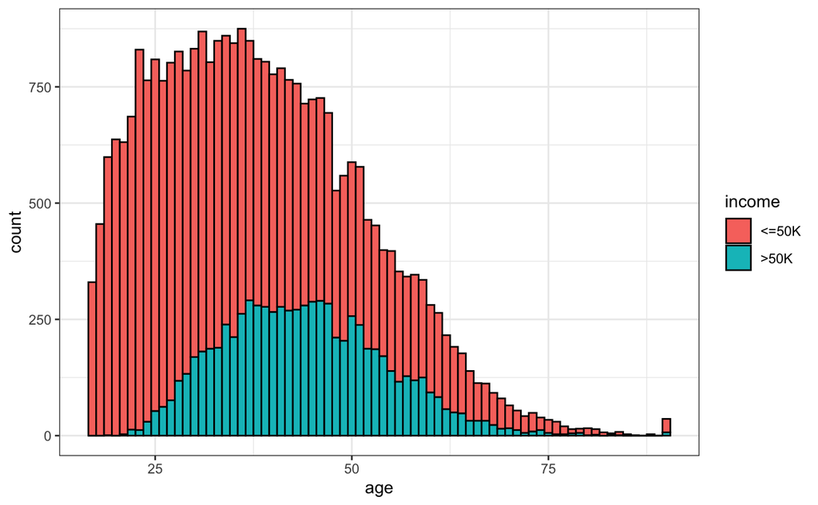

```r
library(ggplot2)
library(dplyr)
ggplot(adult,aes(age)) + geom_histogram(aes(fill=income),color='black',binwidth=1) + theme_bw()
```

### Plot a histogram of hours worked per week

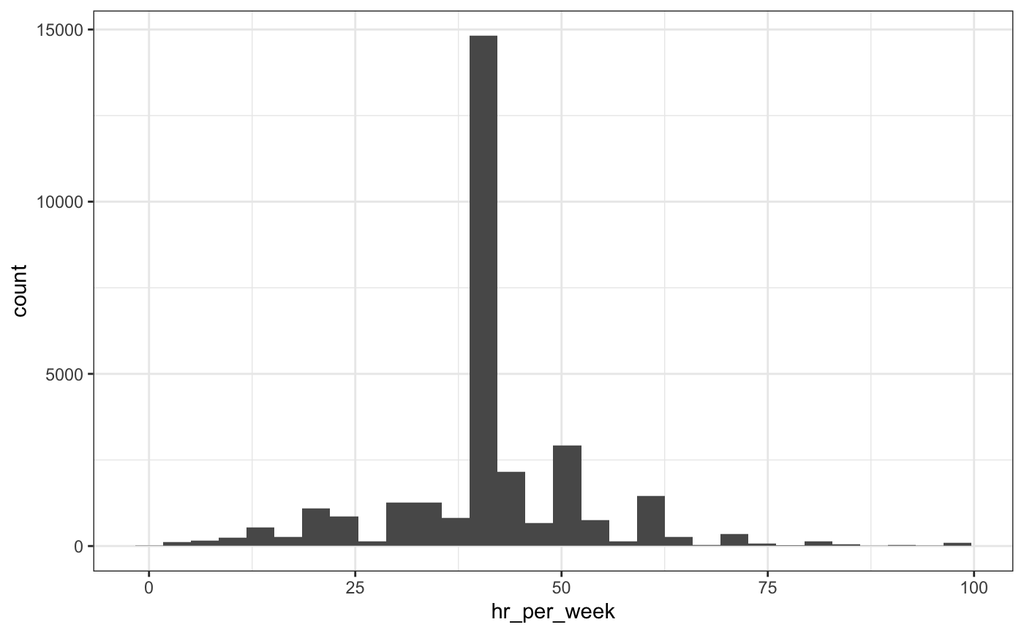

### Rename the country column to region column to better reflect the factor levels.

```r
str(adult)
```

```
'data.frame':   30718 obs. of  15 variables:
 $ age          : int  39 50 38 53 28 37 49 52 31 42 ...
 $ type_employer: Factor w/ 5 levels "SL-gov","self-emp",..: 1 2 3 3 3 3 3 2 3 3 ...
 $ fnlwgt       : int  77516 83311 215646 234721 338409 284582 160187 209642 45781 159449 ...
 $ education    : Factor w/ 16 levels "10th","11th",..: 10 10 12 2 10 13 7 12 13 10 ...
 $ education_num: int  13 13 9 7 13 14 5 9 14 13 ...
 $ marital      : Factor w/ 3 levels "Never-married",..: 1 2 3 2 2 2 2 2 1 2 ...
 $ occupation   : Factor w/ 14 levels "Adm-clerical",..: 1 2 3 3 4 2 5 2 4 2 ...
 $ relationship : Factor w/ 6 levels "Husband","Not-in-family",..: 2 1 2 1 6 6 2 1 2 1 ...
 $ race         : Factor w/ 5 levels "Amer-Indian-Eskimo",..: 5 5 5 3 3 5 3 5 5 5 ...
 $ sex          : Factor w/ 2 levels "Female","Male": 2 2 2 2 1 1 1 2 1 2 ...
 $ capital_gain : int  2174 0 0 0 0 0 0 0 14084 5178 ...
 $ capital_loss : int  0 0 0 0 0 0 0 0 0 0 ...
 $ hr_per_week  : int  40 13 40 40 40 40 16 45 50 40 ...
 $ region       : Factor w/ 5 levels "North.America",..: 1 1 1 1 2 1 2 1 1 1 ...
 $ income       : Factor w/ 2 levels "<=50K",">50K": 1 1 1 1 1 1 1 2 2 2 ...
 - attr(*, "na.action")= 'omit' Named int  28 62 70 78 107 129 150 155 161 188 ...
  ..- attr(*, "names")= chr  "28" "62" "70" "78" ...
```

### Create a barplot of region with the fill color defined by income class. Optional: Figure out how rotate the x axis text for readability

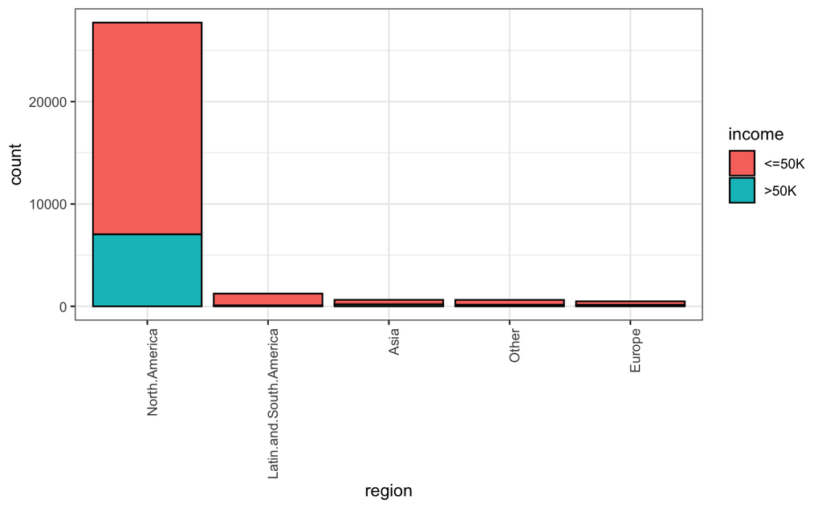

# Building a Model

Now it’s time to build a model to classify people into two groups: Above or Below 50k in Salary. ## Logistic Regression

Refer to the Lecture or ISLR if you are fuzzy on any of this. Logistic Regression is a type of classification model. In classification models, we attempt to predict the outcome of categorical dependent variables, using one or more independent variables. The independent variables can be either categorical or numerical. Logistic regression is based on the logistic function, which always takes values between 0 and 1. Replacing the dependent variable of the logistic function with a linear combination of dependent variables we intend to use for regression, we arrive at the formula for logistic regression. ### Take a quick look at the head() of adult to make sure we have a good overview before going into building the model!

|  | age | type_employer | fnlwgt | education | education_num | marital | occupation | relationship | race | sex | capital_gain | capital_loss | hr_per_week | region | income |
| --- | --- | --- | --- | --- | --- | --- | --- | --- | --- | --- | --- | --- | --- | --- | --- |
| 1 | 39 | SL-gov | 77516 | Bachelors | 13 | Never-married | Adm-clerical | Not-in-family | White | Male | 2174 | 0 | 40 | North.America | <=50K |
| 2 | 50 | self-emp | 83311 | Bachelors | 13 | Married | Exec-managerial | Husband | White | Male | 0 | 0 | 13 | North.America | <=50K |
| 3 | 38 | Private | 215646 | HS-grad | 9 | Not-Married | Handlers-cleaners | Not-in-family | White | Male | 0 | 0 | 40 | North.America | <=50K |
| 4 | 53 | Private | 234721 | 11th | 7 | Married | Handlers-cleaners | Husband | Black | Male | 0 | 0 | 40 | North.America | <=50K |
| 5 | 28 | Private | 338409 | Bachelors | 13 | Married | Prof-specialty | Wife | Black | Female | 0 | 0 | 40 | Latin.and.South.America | <=50K |
| 6 | 37 | Private | 284582 | Masters | 14 | Married | Exec-managerial | Wife | White | Female | 0 | 0 | 40 | North.America | <=50K |

## Train Test Split

### Split the data into a train and test set using the caTools library as done in previous lectures. Reference previous solutions notebooks if you need a refresher.

```r
# Import Library
library(caTools)

# Set a random see so your "random" results are the same as this notebook
set.seed(101)

# Split up the sample, basically randomly assigns a booleans to a new column "sample"
sample <- sample.split(adult$income, SplitRatio = 0.70) # SplitRatio = percent of sample==TRUE

# Training Data
train = subset(adult, sample == TRUE)

# Testing Data
test = subset(adult, sample == FALSE)
```